# Sacred values as index signals of trustworthy character — Reproducibility Pipeline (Studies 1 & 2)

Push-button reproduction of every statistical test reported for Studies 1 and 2, in both the main text and the Supporting Information

Sacred Values project

Knitted 27 July 2026

# 1 What this document is

This is a **single, self-contained reproducibility pipeline** for Studies 1 and 2 of *Sacred values as index signals of trustworthy character*. Knitting it from a clean R session reproduces, from the raw OSF data, **every statistical test reported for these two studies — in both the main text and the Supporting Information (SI)** — and audits each computed value against the number printed in the paper. Concretely it covers:

- the headline trustworthiness contrast, its effect size and probability of superiority (CLES), and the out-group replication (main text);
- the low-sanctity-observer robustness check (main text);
- the pre-registered *parametric* tests, trait by trait and relationship by relationship (SI);
- the sensitivity analysis *without exclusions* (SI);
- the exploratory *selfishness* attribution analyses, including the single and dual mediation models (SI);
- the Shapiro-Wilk normality tests that motivate the non-parametric approach (SI); and
- the inter-correlation matrices among the key variables (SI), plus the Study 2 sacralizing-of-friendship and closeness-to-community effects (SI).

**Design standard: push-button replication** (Wood, Müller & Brown, *PLOS ONE* 2018): a third party should be able to take the archived data and code and *“push the button”* to reproduce the published results **without contacting the authors**. Concretely, this file is built to satisfy their criteria:

| Push-button criterion | How this document meets it |
| --- | --- |
| Ready-to-run, no author intervention | One `.Rmd`; `Knit` runs everything top to bottom. |
| Raw data + analysis code together | Reads the original `.sav` files directly; no hidden intermediate datasets. |
| No machine-specific paths | Data location is auto-detected by walking up the directory tree; no absolute paths, no `setwd()`. |
| Data structure matches code | Sample sizes are **asserted** (`stopifnot`) against the paper’s reported *N*; the knit fails loudly if the data drifted. |
| Key results declared in advance | Reported values are written into a target table *before* the data are analysed, then compared automatically. |
| Documented software environment | Full `sessionInfo()` and package versions are printed at the end. |
| Reproducible randomness | A single global seed is set; every bootstrap additionally fixes its own seed. |

No original SPSS syntax survived, so the analyses here are a from-scratch rebuild guided by the OSF variable keys. The fact that the rebuilt numbers match the paper (see the audit tables) is itself the evidence that the rebuild is faithful.

# 2 Setup

## 2.1 Packages, seed, and data location

```r
suppressPackageStartupMessages({
  library(haven)    # read SPSS .sav
  library(dplyr)    # data manipulation
  library(coin)     # Mann-Whitney with exact standardized Z
  library(ggplot2)  # figures
  library(tibble)   # tidy result tables
  library(knitr)    # kable tables
})

# One seed for the whole document (YYYYMMDD). Every bootstrap below also fixes its own
# seed so the confidence intervals are byte-for-byte reproducible.
set.seed(20260619)
```

The data live in a `data/` folder (a copy of the OSF archive at https://osf.io/ju9rq/). Rather than hard-code a path, we locate that folder by walking up from wherever this file is knitted. To run against data stored elsewhere, set `DATA_DIR` by hand in the chunk below.

```r
# Walk up the directory tree until we find a folder containing `marker`.
find_data_root <- function(start = getwd(), marker = "data") {
  d <- normalizePath(start, winslash = "/", mustWork = FALSE)
  repeat {
    if (dir.exists(file.path(d, marker))) return(d)
    parent <- dirname(d)
    if (identical(parent, d)) {
      stop("Could not locate the '", marker, "' directory by walking up from ",
           start, ".\n  Set DATA_DIR manually in this chunk.", call. = FALSE)
    }
    d <- parent
  }
}

DATA_DIR <- file.path(find_data_root(), "data")   # <- override here if needed

s1_file <- file.path(DATA_DIR, "Study 1 - Sacred Ring",    "OSF SV Trust - Study 1.sav")
s2_file <- file.path(DATA_DIR, "Study 2 - Pork Investment", "OSF SV Trust - Study 2.sav")

# Fail early and clearly if the data are not where we expect.
stopifnot(
  "Study 1 .sav not found" = file.exists(s1_file),
  "Study 2 .sav not found" = file.exists(s2_file)
)
cat("Data directory:\n  ", DATA_DIR, "\n")
```

```
## Data directory:
##    /Users/thandfie/Library/CloudStorage/Dropbox/Toby-Ji-shared-folder/Sacred Values Experiment/paper/PNAS version/sacred-values-reproducibility/data
```

## 2.2 Statistical helper functions

These functions do all the statistical work. They are defined here, in the open, so a sceptical reader can audit every line. (Click the **Code** toggle to collapse them.)

```r
# Mean of a set of items, coercing SPSS labelled columns to plain numeric -----
composite <- function(df, items) {
  rowMeans(sapply(items, function(v) as.numeric(df[[v]])), na.rm = TRUE)
}

# Cronbach's alpha (raw) for a data frame / matrix of items -------------------
cronbach_alpha <- function(df, items) {
  m <- sapply(items, function(v) as.numeric(df[[v]]))
  m <- m[stats::complete.cases(m), , drop = FALSE]
  k <- ncol(m)
  (k / (k - 1)) * (1 - sum(apply(m, 2, stats::var)) / stats::var(rowSums(m)))
}

# Mann-Whitney U test with the exact standardized Z (via coin) ----------------
# Returns both U conventions. The main text reports U_max (the larger U); a few SI
# effects are printed as U_min, so both are available. Effect size r = |Z| / sqrt(N).
mann_whitney <- function(dv, group) {
  group <- droplevels(as.factor(group))
  stopifnot(nlevels(group) == 2)
  d <- data.frame(dv = as.numeric(dv), group = group)
  d <- d[stats::complete.cases(d), ]
  N <- nrow(d)

  wt <- coin::wilcox_test(dv ~ group, data = d, distribution = "asymptotic")
  Z  <- as.numeric(coin::statistic(wt, type = "standardized"))
  p  <- coin::pvalue(wt)

  w  <- stats::wilcox.test(dv ~ group, data = d, exact = FALSE, correct = FALSE)
  g1 <- d$group == levels(d$group)[1]
  g2 <- d$group == levels(d$group)[2]
  n1 <- sum(g1); n2 <- sum(g2)
  U1 <- as.numeric(w$statistic)
  U2 <- n1 * n2 - U1
  rk <- rank(d$dv)   # pooled ranks -> per-group mean ranks, as SPSS prints them

  list(U1 = U1, U2 = U2, U_min = min(U1, U2), U_max = max(U1, U2),
       Z = Z, absZ = abs(Z), p = p, r = abs(Z) / sqrt(N), N = N, n1 = n1, n2 = n2,
       mean_rank1 = mean(rk[g1]), mean_rank2 = mean(rk[g2]),
       M1 = mean(d$dv[g1]), SD1 = sd(d$dv[g1]),
       M2 = mean(d$dv[g2]), SD2 = sd(d$dv[g2]))
}

# Welch two-sample t test with Cohen's d (pooled SD) --------------------------
# x: 0/1 group code (1 = sacred). t and d are signed sacred - non-sacred (positive
# when the sacred target scores higher).
welch_d <- function(dv, x) {
  d  <- data.frame(dv = as.numeric(dv), g = as.integer(x))
  d  <- d[stats::complete.cases(d), ]
  g1 <- d$dv[d$g == 1]; g0 <- d$dv[d$g == 0]
  tt <- stats::t.test(g1, g0)                                # Welch (unequal variance)
  n1 <- length(g1); n0 <- length(g0)
  sp <- sqrt(((n1 - 1) * stats::var(g1) + (n0 - 1) * stats::var(g0)) / (n1 + n0 - 2))
  tibble(t = unname(tt$statistic), df = unname(tt$parameter), p = tt$p.value,
         d  = (mean(g1) - mean(g0)) / sp,
         M1 = mean(g1), SD1 = stats::sd(g1), M0 = mean(g0), SD0 = stats::sd(g0),
         n1 = n1, n0 = n0)
}

# Simple mediation, Hayes PROCESS Model 4 -------------------------------------
# x: 0/1 (0 = non-sacred, 1 = sacred); m, y: numeric outcomes.
# Indirect effect a*b with a bias-corrected bootstrap CI (the PROCESS default).
mediation_m4 <- function(x, m, y, n_boot = 5000, seed = 2024, conf = 0.95) {
  d <- data.frame(x = as.numeric(x), m = as.numeric(m), y = as.numeric(y))
  d <- d[stats::complete.cases(d), ]

  point <- function(dd) {
    a  <- stats::coef(stats::lm(m ~ x, data = dd))[["x"]]
    bm <- stats::lm(y ~ x + m, data = dd)
    b  <- stats::coef(bm)[["m"]]
    cp <- stats::coef(bm)[["x"]]                              # direct effect c'
    c  <- stats::coef(stats::lm(y ~ x, data = dd))[["x"]]      # total effect c
    c(a = a, b = b, cprime = cp, total = c, indirect = a * b)
  }
  est <- point(d)

  set.seed(seed)                                              # reproducible bootstrap
  n  <- nrow(d)
  bs <- replicate(n_boot, {
    dd <- d[sample.int(n, n, replace = TRUE), ]
    tryCatch(point(dd)[["indirect"]], error = function(e) NA_real_)
  })
  bs <- bs[is.finite(bs)]

  # Bias-corrected interval (BCa with acceleration = 0)
  z0 <- stats::qnorm(mean(bs < est[["indirect"]]))
  za <- stats::qnorm(c((1 - conf) / 2, 1 - (1 - conf) / 2))
  ci <- stats::quantile(bs, c(stats::pnorm(2 * z0 + za[1]),
                              stats::pnorm(2 * z0 + za[2])), names = FALSE)

  list(n = n, n_boot = length(bs), unstd = est, indirect = est[["indirect"]],
       direct = est[["cprime"]], ci = ci, boot_se = stats::sd(bs))
}

# Dual (parallel) mediation with two mediators m1, m2 -------------------------
# Returns the two indirect effects and the direct effect, each with a
# bias-corrected bootstrap CI. Used for the Study 1 selfishness + trust dual model.
mediation_dual <- function(x, m1, m2, y, n_boot = 5000, seed = 2024, conf = 0.95) {
  d <- data.frame(x = as.numeric(x), m1 = as.numeric(m1),
                  m2 = as.numeric(m2), y = as.numeric(y))
  d <- d[stats::complete.cases(d), ]
  point <- function(dd) {
    a1 <- stats::coef(stats::lm(m1 ~ x, data = dd))[["x"]]
    a2 <- stats::coef(stats::lm(m2 ~ x, data = dd))[["x"]]
    ym <- stats::lm(y ~ x + m1 + m2, data = dd)
    c(i1 = a1 * stats::coef(ym)[["m1"]], i2 = a2 * stats::coef(ym)[["m2"]],
      dir = stats::coef(ym)[["x"]])
  }
  est <- point(d)
  set.seed(seed); n <- nrow(d)
  bs <- replicate(n_boot, {
    dd <- d[sample.int(n, n, replace = TRUE), ]
    tryCatch(point(dd), error = function(e) c(i1 = NA, i2 = NA, dir = NA))
  })
  bc <- function(pt, draws) {
    draws <- draws[is.finite(draws)]
    z0 <- stats::qnorm(mean(draws < pt))
    za <- stats::qnorm(c((1 - conf) / 2, 1 - (1 - conf) / 2))
    stats::quantile(draws, stats::pnorm(2 * z0 + za), names = FALSE)
  }
  list(est = est,
       i1 = bc(est[["i1"]], bs["i1", ]),
       i2 = bc(est[["i2"]], bs["i2", ]),
       dir = bc(est[["dir"]], bs["dir", ]))
}

# Probability of superiority / common-language effect size (CLES) -------------
# P(a random draw from `high` exceeds a random draw from `low`); ties count 1/2.
prob_superiority <- function(high, low) {
  high <- high[!is.na(high)]; low <- low[!is.na(low)]
  mean(outer(high, low, function(a, b) (a > b) + 0.5 * (a == b)))
}
```

```r
# Build one audit row: computed value vs the paper's reported (or corrected) value.
# tol = absolute tolerance for a "match"; up to 3*tol is "close".
audit_row <- function(quantity, computed, claimed, tol, digits = 2) {
  fmt <- function(v) if (is.na(v)) "--" else formatC(v, format = "f", digits = digits)
  check <- if (is.na(claimed)) "not stated in text"
           else {
             d <- abs(computed - claimed)
             if (d <= tol) "match" else if (d <= 3 * tol) "close" else "DIFFERS"
           }
  tibble(Quantity   = quantity,
         Reported   = fmt(claimed),
         Computed   = fmt(computed),
         Check      = check)
}

# Per-item comparison table: Welch t / d for each item, with the SI-printed t and d
# shown alongside as a reproduction check (computed and SI values should agree).
item_table <- function(df, items, labels, si_t, si_d) {
  dplyr::bind_rows(lapply(seq_along(items), function(i) {
    r <- welch_d(df[[items[i]]], df$x)
    tibble(Item        = labels[i],
           `M sacred`  = sprintf("%.2f", r$M1),
           `M non-sac` = sprintf("%.2f", r$M0),
           t           = sprintf("%.2f", r$t),
           df          = sprintf("%.1f", r$df),
           d           = sprintf("%.2f", r$d),
           `SI t`      = sprintf("%.2f", si_t[i]),
           `SI d`      = sprintf("%.2f", si_d[i]))
  }))
}
```

# 3 Study 1 — Sacred Ring (within-culture)

> *“Alex”* refuses (sacred) or accepts (non-sacred) $20,000 for a wedding ring bought for $2,000. U.S. representative sample. Reported $N = 281$.

## 3.1 Load, exclude, and build measures

```r
s1 <- read_sav(s1_file)

# Pre-registered exclusions: keep Exclusion == 0 ("Good").
s1a <- s1 %>% filter(Exclusion == 0)

# Condition: string "Sell" / "Sacred" -> x = 1 for the sacred (refuser) target.
cond_raw <- as_factor(s1a$Condition)
s1a$x    <- as.integer(cond_raw == "Sacred")
s1a$cond <- factor(s1a$x, levels = c(0, 1),
                   labels = c("Non-sacred (sold)", "Sacred (refused)"))

# Composites and single-item measures (per OSF variable key):
#   trust    = mean(Trust_Att_1..6)  [committed, respectful, trustworthy,
#                                      credible, reliable, benevolent]
#   accept   = mean(Rel_1..4)        [friend, romantic, colleague, boss]
#   selfish  = Trust_Att_7           (NOT part of the trust scale)
#   joint    = Joint_D               (importance of joint decision-making)
#   psv      = P_SV                  (participant's own sacralizing of symbolic items)
s1a$trust   <- composite(s1a, paste0("Trust_Att_", 1:6))
s1a$accept  <- composite(s1a, paste0("Rel_", 1:4))
s1a$selfish <- as.numeric(s1a$Trust_Att_7)
s1a$joint   <- as.numeric(s1a$Joint_D)
s1a$psv     <- as.numeric(s1a$P_SV)

# Push-button check: the data must have the N the paper claims.
stopifnot("Study 1 N after exclusions != 281" = nrow(s1a) == 281L)

# And our hand-built composites must equal the pre-baked OSF columns.
stopifnot(
  max(abs(s1a$trust  - s1a$Trust_C),  na.rm = TRUE) < 1e-6,
  max(abs(s1a$accept - s1a$Rel_Comp), na.rm = TRUE) < 1e-6
)

table(s1a$cond)
```

```
##
## Non-sacred (sold)  Sacred (refused)
##               143               138
```

## 3.2 Scale reliability

```r
s1_alpha_trust  <- cronbach_alpha(s1a, paste0("Trust_Att_", 1:6))
s1_alpha_accept <- cronbach_alpha(s1a, paste0("Rel_", 1:4))
c(trust_alpha = round(s1_alpha_trust, 3), accept_alpha = round(s1_alpha_accept, 3))
```

```
##  trust_alpha accept_alpha
##        0.934        0.910
```

## 3.3 Descriptives by condition

```r
s1_desc <- s1a %>%
  group_by(Condition = cond) %>%
  summarise(n = n(),
            trust_M  = mean(trust),  trust_SD  = sd(trust),
            accept_M = mean(accept), accept_SD = sd(accept),
            .groups = "drop")
s1_desc
```

| Condition | n | trust_M | trust_SD | accept_M | accept_SD |
| --- | --- | --- | --- | --- | --- |
| Non-sacred (sold) | 143 | 56.38928 | 20.49940 | 49.47378 | 24.93435 |
| Sacred (refused) | 138 | 86.47222 | 10.77567 | 82.36594 | 16.20081 |

## 3.4 Trustworthiness contrast (Mann-Whitney U) — *main text*

```r
s1_mw  <- mann_whitney(s1a$trust, s1a$cond)
s1_pos <- prob_superiority(s1a$trust[s1a$x == 1], s1a$trust[s1a$x == 0])

with(s1_mw, cat(sprintf(
  "U_max = %.1f (U_min = %.1f) | Z = %.2f | p = %.2e | r = %.2f | N = %d\n",
  U_max, U_min, absZ, p, r, N)))
```

```
## U_max = 17786.5 (U_min = 1947.5) | Z = 11.63 | p = 2.82e-31 | r = 0.69 | N = 281
```

```r
cat(sprintf("Probability of superiority / CLES (sacred > non-sacred) = %.3f\n", s1_pos))
```

```
## Probability of superiority / CLES (sacred > non-sacred) = 0.901
```

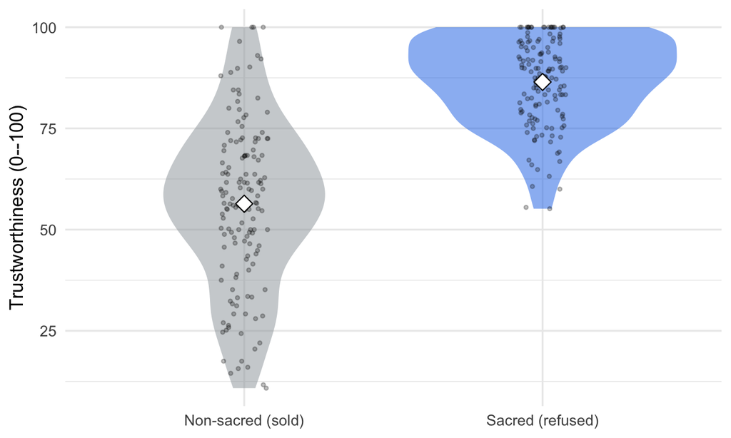

Study 1: distribution of trustworthiness ratings by condition. Diamonds mark condition means.

```r
ggplot(s1a, aes(cond, trust, fill = cond)) +
  geom_violin(alpha = 0.5, colour = NA, width = 0.9) +
  geom_jitter(width = 0.08, height = 0, alpha = 0.25, size = 0.9) +
  stat_summary(fun = mean, geom = "point", shape = 23, size = 4,
               fill = "white", colour = "black") +
  scale_fill_manual(values = c("#9aa0a6", "#1a73e8"), guide = "none") +
  labs(x = NULL, y = "Trustworthiness (0--100)") +
  theme_minimal(base_size = 13)
```

## 3.5 Robustness: observers who do not share the value — *main text*

The effect does not require the observer to hold the particular value. We re-run the contrast within participants who scored **low** on personal sanctification of symbolic objects (`P_SV_GRP == 1`, i.e. $\geq 1$ SD below the mean).

```r
# Verify P_SV_GRP grouping is consistent with the continuous P_SV composite
stopifnot(all(s1$P_SV[s1$P_SV_GRP == 1] <= 2.8))
stopifnot(all(s1$P_SV[s1$P_SV_GRP == 3] >= 5.6))

s1_low <- s1a %>% filter(P_SV_GRP == 1)
s1_mw_low <- mann_whitney(s1_low$trust, s1_low$cond)

with(s1_mw_low, cat(sprintf(
  "Low-sanctity subgroup (n = %d): U_max = %.1f | Z = %.2f | p = %.3f | r = %.2f\n",
  N, U_max, absZ, p, r)))
```

```
## Low-sanctity subgroup (n = 44): U_max = 322.5 | Z = 2.84 | p = 0.005 | r = 0.43
```

## 3.6 Normality assumption tests — *SI*

The SI reports Shapiro-Wilk tests to justify the non-parametric main analysis. All four key variables depart from normality.

```r
s1_norm <- tibble(
  Variable = c("Trust attribution", "Interpersonal relationships",
               "Joint decision-making", "Participant's own sacred values"),
  W = c(shapiro.test(s1a$trust)$statistic,  shapiro.test(s1a$accept)$statistic,
        shapiro.test(s1a$joint)$statistic,  shapiro.test(s1a$psv)$statistic),
  p = c(shapiro.test(s1a$trust)$p.value,    shapiro.test(s1a$accept)$p.value,
        shapiro.test(s1a$joint)$p.value,    shapiro.test(s1a$psv)$p.value),
  `SI W` = c(.94, .94, .83, .98)
)
s1_norm %>% mutate(W = round(W, 3), p = signif(p, 3))
```

| Variable | W | p | SI W |
| --- | --- | --- | --- |
| Trust attribution | 0.938 | 0.00000 | 0.94 |
| Interpersonal relationships | 0.941 | 0.00000 | 0.94 |
| Joint decision-making | 0.834 | 0.00000 | 0.83 |
| Participant’s own sacred values | 0.983 | 0.00207 | 0.98 |

## 3.7 Pre-registered parametric tests — *SI*

The SI reports the pre-registered *t*-tests (main analysis uses non-parametric tests because of the normality violations above). Composite trust and composite interpersonal relationships first, then trait by trait and relationship by relationship. Cohen’s *d* uses the pooled SD.

```r
s1_t_trust  <- welch_d(s1a$trust,  s1a$x)
s1_t_accept <- welch_d(s1a$accept, s1a$x)

cat(sprintf("Trust composite:          t(%.2f) = %.2f, p = %.2e, d = %.2f\n",
            s1_t_trust$df,  s1_t_trust$t,  s1_t_trust$p,  s1_t_trust$d))
```

```
## Trust composite:          t(216.56) = 15.47, p = 7.22e-37, d = 1.83
```

```r
cat(sprintf("Interpersonal composite:  t(%.2f) = %.2f, p = %.2e, d = %.2f\n",
            s1_t_accept$df, s1_t_accept$t, s1_t_accept$p, s1_t_accept$d))
```

```
## Interpersonal composite:  t(244.85) = 13.16, p = 2.91e-30, d = 1.56
```

```r
# Per-trait t-tests, with the SI-reported t and d alongside for direct comparison.
item_table(
  s1a, paste0("Trust_Att_", 1:6),
  c("Committed", "Respectful", "Trustworthy", "Credible", "Reliable", "Benevolent"),
  si_t = c(16.12, 14.65, 14.20, 11.39, 12.88, 6.62),
  si_d = c(1.90,  1.74,  1.69,  1.35,  1.53,  0.79)
)
```

| Item | M sacred | M non-sac | t | df | d | SI t | SI d |
| --- | --- | --- | --- | --- | --- | --- | --- |
| Committed | 94.56 | 58.23 | 16.12 | 175.6 | 1.90 | 16.12 | 1.90 |
| Respectful | 89.61 | 55.25 | 14.65 | 207.6 | 1.73 | 14.65 | 1.74 |
| Trustworthy | 89.41 | 56.63 | 14.20 | 202.3 | 1.68 | 14.20 | 1.69 |
| Credible | 85.95 | 59.43 | 11.39 | 244.3 | 1.35 | 11.39 | 1.35 |
| Reliable | 87.39 | 56.82 | 12.88 | 244.8 | 1.53 | 12.88 | 1.53 |
| Benevolent | 71.91 | 51.97 | 6.62 | 269.1 | 0.79 | 6.62 | 0.79 |

```r
# Per-relationship t-tests, SI values alongside.
item_table(
  s1a, paste0("Rel_", 1:4),
  c("Close friend", "Romantic partner", "Work colleague", "Boss/supervisor"),
  si_t = c(12.45, 12.64, 8.67, 10.39),
  si_d = c(1.48,  1.50,  1.03, 1.24)
)
```

| Item | M sacred | M non-sac | t | df | d | SI t | SI d |
| --- | --- | --- | --- | --- | --- | --- | --- |
| Close friend | 86.83 | 53.54 | 12.49 | 224.2 | 1.48 | 12.45 | 1.48 |
| Romantic partner | 82.49 | 39.70 | 12.64 | 273.6 | 1.50 | 12.64 | 1.50 |
| Work colleague | 81.19 | 57.05 | 8.67 | 262.4 | 1.03 | 8.67 | 1.03 |
| Boss/supervisor | 78.96 | 47.61 | 10.42 | 275.4 | 1.24 | 10.39 | 1.24 |